# Modelos Conjuntos para Dados Longitudinais e de Sobrevivência

Um tutorial usando o pacote JM

Maria Helena Oliveira e Isolde Previdelli

# Apresentação

Este material foi desenvolvido como apoio para um Tutorial ministrado durante a 67ª RBRAS e 20° SEAGRO, e é baseado no livro do professor Dimitris Rizopoulos, autor do pacote `JM`.

# Motivação

A modelagem conjunta pode ser considerada como uma ferramenta de análise muito útil particularmente em dois cenários:

- Quando estudamos um desfecho de tempo de sobrevida e temos interesse em uma **covariável endógena medida ao longo do tempo**.
- Quando estudamos um desfecho longitudinal e precisamos acomodar **perda ou truncamento não aleatório**.

O primeiro cenário é muito comum no estudo de biomarcadores associados à progressão de doenças, como a carga viral de pacientes infectados com HIV, comumente associada ao tempo até o desenvolvimento de AIDS ou o óbito. O acompanhamento dos pacientes ao longo do tempo acarreta invariavelmente em medidas repetidas dos biomarcadores importantes até que o evento de interesse ocorra.

Nestes casos, o biomarcador observado pode ser descrito como uma covariável tempo-dependente *endógena*, dado que a sua observação depende da não ocorrência do evento.

O segundo cenário se caracteriza pelo truncamento da trajetória longitudinal da variável de interesse quando o evento ocorre. Por exemplo, ao estudar a propagação de uma doença em plantas, a planta pode morrer antes do término das observações planejadas, e se a quantidade de doença está associada à morte da planta, este é um mecanismo de perda não aleatório.

- Quando o evento estudado não é um mecanismo de perda da covariável tempo-dependente, a modelagem conjunta ainda pode ser vantajosa na presença de uma covariável que é medida com erro ou com ruído.

## Dados do pacote JM

o banco de dados `prothro` do pacote JM contém informações de um ensaio clínico aleatorizado conduzido com objetivo de verificar o efeito da prednisona sobre um marcador de função hepática chamado índice de protrombina em pacientes com cirrose. Os pacientes foram randomizados para receber prednisona ou placebo e acompanhados aos 3, 6 e 12 meses, e anualmente após isso, até a sua morte ou censura (morte não relacionada ou perda de acompanhamento).

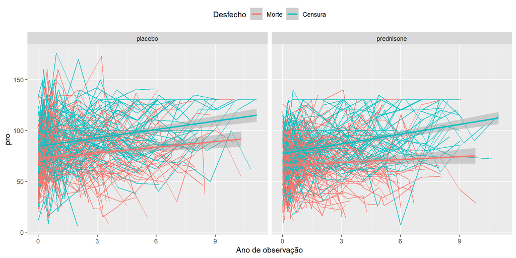

- No gráfico podemos observar que pacientes que vão a óbito tem, em geral, menor índice de protrombina, e são acompanhados por menos tempo. Se valores menores tem menor probabilidade de serem observados, por estarem associados à morte do paciente, esse pode ser um mecanismo de perda não aleatória.
- Como a observação da protrombina depende da não ocorrência do evento, essa contagem também pode ser considerada uma variável endógena, e a sua inclusão em um modelo de riscos proporcionais como covariável tempo-dependente pode levar a estimativas viesadas.

# Modelos de efeitos mistos

## Definição

Quando tratamos de dados longitudinais, é esperado que exista alguma estrutura de correlação nos dados que precisa ser levada em consideração na análise estatística, de modo que medidas de um mesmo indivíduo ao longo do tempo são correlacionadas entre si, enquanto medidas de indivíduos diferentes são independentes umas das outras.

Um método muito popular para a análise de dados longitudinais é a introdução de efeitos aleatórios em modelos de regressão tradicionais, gerando modelos de efeitos mistos.

Um modelo linear misto geral pode ser definido como:

$$\begin{equation}
\begin{cases}
\pmb y_i = X_i \pmb\beta + Z_i \pmb b_i + \pmb\varepsilon_i,\\
\pmb b_i \sim \mathcal{N} (0, D),\\
\pmb{\varepsilon}_i \sim \mathcal{N}(0, \sigma^2 \pmb I_{n_i}),
\end{cases}
\end{equation}$$

em que $\pmb y_i$ é um vetor de respostas de dimensão $n_i$ que assume valores $y_{ij}$ para o $i$-ésimo indivíduo no $j$-ésimo momento. $X_i$ e $Z_i$ são matrizes-modelo conhecidas, para os coeficientes de efeito fixo $\pmb\beta$ e de efeito aleatório $\pmb b_i$. Uma distribuição normal multivariada com média zero e matriz de variância e covariância $D$ é asumida para os efeitos aleatórios, que são independentes dos termos de erro $\pmb\varepsilon_i$, também normalmente distribuídos com média zero e matriz de variância $\sigma^2 I_{n_i}$.

Este modelo pode ser estimado pelo método de máxima verossimilhança restrita.

## Exemplo

Para o ajuste destes modelos no software R, vamos usar o pacote `nlme`. Podemos introduzir efeitos aleatórios no intercepto ou na inclinação das trajetórias ao longo do tempo, dependendo da variação esperada no comportamento dos indivíduos.

Para ilustrar essa variação, vamos ver o gráfico do exemplo anterior, mas agora com retas ajustadas para cada indivíduo.

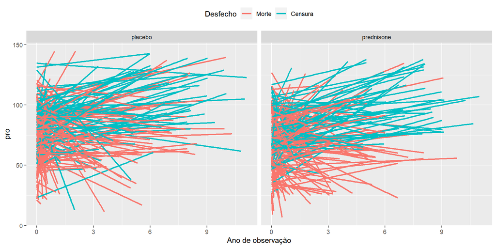

- As trajetórias de cada indivíduo também não são paralelas: alguns podem ter trajetórias crescentes, e outros decrescentes ao longo do tempo.
- Tanto o intercepto como a inclinação das trajetórias podem estar associados a características intrínsecas de cada indivíduo, que variam aleatoriamente entre eles
- Quando se assume apenas um efeito aleatório para cada indivíduo, é induzida uma estrutura de correlação de **simetria composta**, em que todas as observações do mesmo indivíduo são correlacionadas da mesma maneira, sem levar em consideração a distância de tempo entre elas.
- Quando se introduz um efeito aleatório de tempo, a estrutura de correlação induzida leva a uma função de variância marginal que depende de $t$, e espera-se que a variância aumente com o tempo, enquanto a correlação diminua, levando a um modelo com erros heterocedásticos.

**Modelo linear sem efeitos aleatórios**

```r
#modelo sem efeitos aleatórios

modelo1 <- lm(pro ~ time*treat, prothro)

summary(modelo1)
```

```
##
## Call:
## lm(formula = pro ~ time * treat, data = prothro)
##
## Residuals:
##     Min      1Q  Median      3Q     Max
## -80.223 -18.836   0.067  18.825  96.223
##
## Coefficients:
##                      Estimate Std. Error t value Pr(>|t|)
## (Intercept)           77.3202     0.9003  85.881  < 2e-16 ***
## time                   2.6941     0.2825   9.537  < 2e-16 ***
## treatprednisone       -8.3019     1.2836  -6.468 1.16e-10 ***
## time:treatprednisone   0.3421     0.4170   0.820    0.412
## ---
## Signif. codes:  0 '***' 0.001 '**' 0.01 '*' 0.05 '.' 0.1 ' ' 1
##
## Residual standard error: 26.24 on 2964 degrees of freedom
## Multiple R-squared:  0.07977,    Adjusted R-squared:  0.07883
## F-statistic: 85.64 on 3 and 2964 DF,  p-value: < 2.2e-16
```

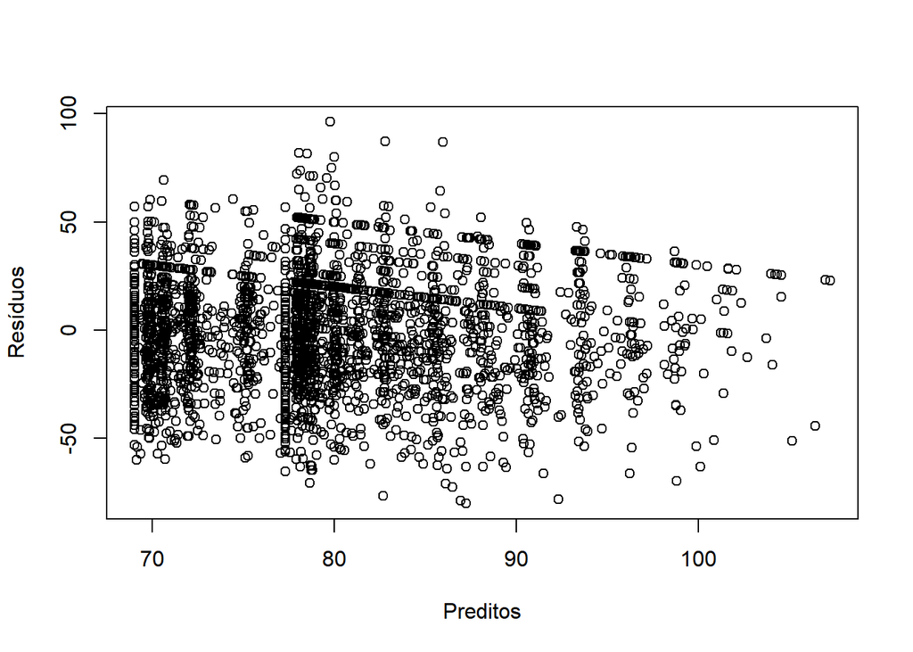

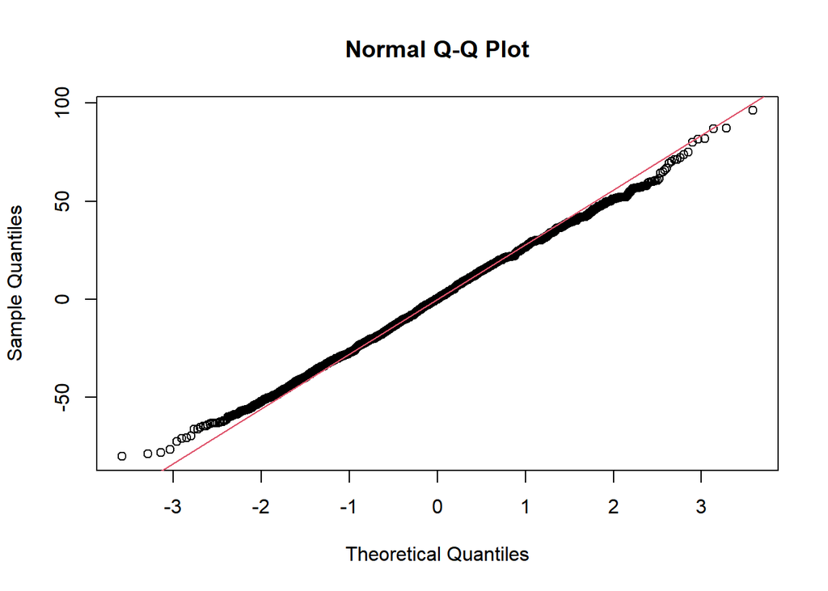

**Modelo linear com intercepto aleatório**

```r
modelo2 <- lme(pro ~ time * treat, prothro, random = ~ 1 | id)

summary(modelo2)
```

```
## Linear mixed-effects model fit by REML
##   Data: prothro
##        AIC      BIC    logLik
##   26671.68 26707.65 -13329.84
##
## Random effects:
##  Formula: ~1 | id
##         (Intercept) Residual
## StdDev:    18.94835 18.56747
##
## Fixed effects:  pro ~ time * treat
##                         Value Std.Error   DF  t-value p-value
## (Intercept)          76.55581 1.3770676 2478 55.59336  0.0000
## time                  1.51487 0.2310050 2478  6.55775  0.0000
## treatprednisone      -7.26374 1.9696037  486 -3.68792  0.0003
## time:treatprednisone  0.47828 0.3403695 2478  1.40518  0.1601
##  Correlation:
##                      (Intr) time   trtprd
## time                 -0.252
## treatprednisone      -0.699  0.177
## time:treatprednisone  0.171 -0.679 -0.259
##
## Standardized Within-Group Residuals:
##        Min         Q1        Med         Q3        Max
## -4.4180408 -0.5867533  0.0126882  0.5921245  3.7716715
##
## Number of Observations: 2968
## Number of Groups: 488
```

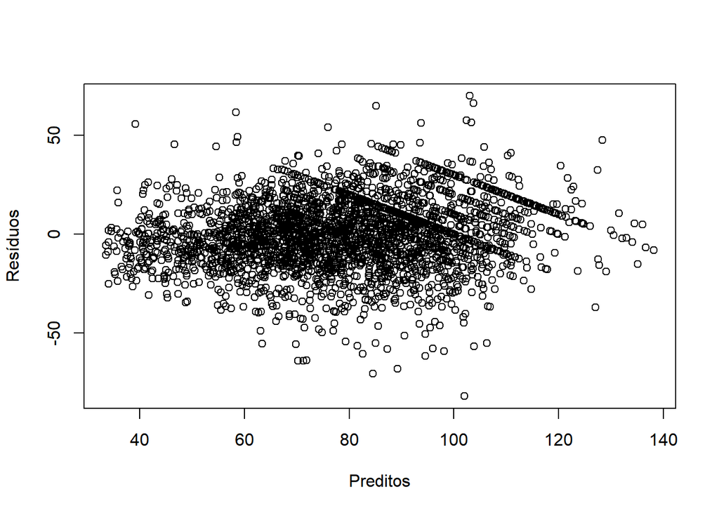

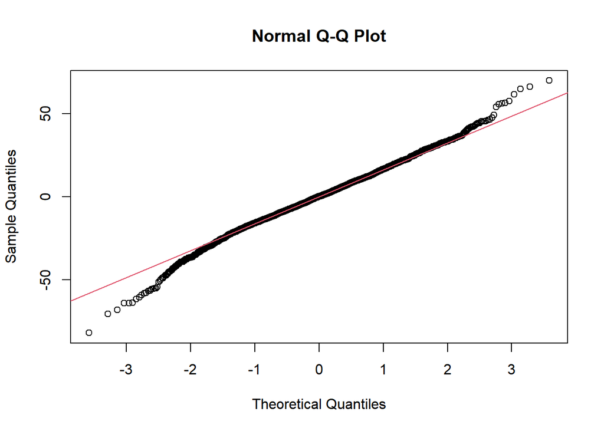

**Modelo linear com intercepto e inclinação aleatórios**

```r
modelo3 <- lme(pro ~ time * treat, prothro, random = ~ time | id)

summary(modelo3)
```

```
## Linear mixed-effects model fit by REML
##   Data: prothro
##        AIC      BIC    logLik
##   26557.59 26605.54 -13270.79
##
## Random effects:
##  Formula: ~time | id
##  Structure: General positive-definite, Log-Cholesky parametrization
##             StdDev   Corr
## (Intercept) 18.41625 (Intr)
## time         3.62703 -0.001
## Residual    17.34742
##
## Fixed effects:  pro ~ time * treat
##                         Value Std.Error   DF  t-value p-value
## (Intercept)          76.87210 1.3360422 2478 57.53718  0.0000
## time                  1.00848 0.4218889 2478  2.39038  0.0169
## treatprednisone      -7.32381 1.9123739  486 -3.82970  0.0001
## time:treatprednisone  0.51347 0.6047411 2478  0.84908  0.3959
##  Correlation:
##                      (Intr) time   trtprd
## time                 -0.191
## treatprednisone      -0.699  0.133
## time:treatprednisone  0.133 -0.698 -0.201
##
## Standardized Within-Group Residuals:
##          Min           Q1          Med           Q3          Max
## -4.583339529 -0.566837093  0.002032327  0.544491368  3.886901146
##
## Number of Observations: 2968
## Number of Groups: 488
```

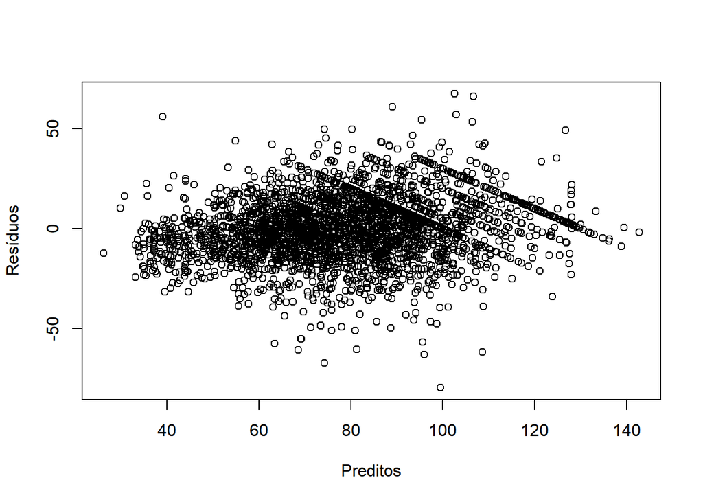

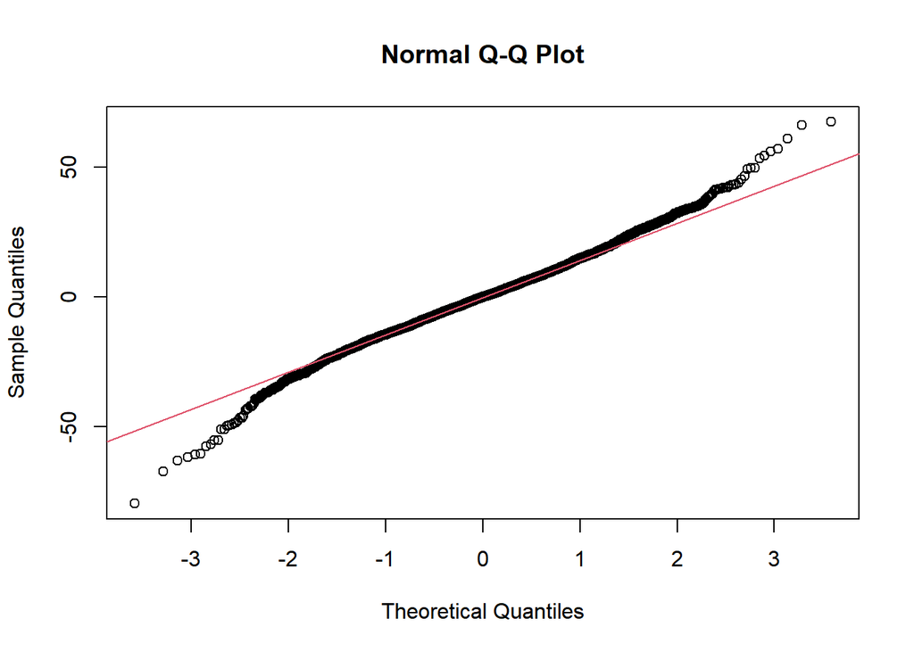

É importante considerar:

- O desvio padrão estimado para os efeitos aleatórios
- Amplitude e distribuição dos resíduos
- Medidas de ajuste como AIC e BIC

O modelo é interpretado de forma análoga a modelos de regressão linear.

# Análise de sobrevivência

Análise de sobrevivência é o conjunto de técnicas para análise de dados de tempo até um certo evento. Este tipo de dado é caracterizado pela presença de *censura*.

A censura é uma observação incompleta do desfecho. Quando a variável de interesse é o tempo de sobrevida, ou seja, o tempo até que o óbito ocorra, é comum que não seja possível acompanhar todos os sujeitos até a ocorrência do evento, por diversos motivos:

- perda de acompanhamento ou desistência de participar do estudo
- óbito por motivo não relacionado ao estudo
- fim do período de acompanhamento do estudo

O tipo mais comum de censura é chamado de **censura à direita**, quando sabemos que o tempo de evento real é maior do que o observado. Na presença deste tipo de dados, é necessário incorporar as observações censuradas.

Para caracterizar esse tipo de dados, definimos uma variável $\delta_i$ que assume valor 1 quando o evento ocorre para o $i$-ésimo indivíduo, e zero quando não ocorre (censurado à direita).

$$\begin{equation}
\delta_{i} =
\begin{cases}
1 & \text{se o evento ocorreu}\\
0 & \text{se o indivíduo for censurado, para $i = 1, 2, ...,
n$.}\\
\end{cases}
\end{equation}$$

A *função de sobrevivência* $S(t)$ é definida como a probabilidade de que o evento ocorra após um certo tempo $t$, ou seja, a probabilidade de um indivíduo sobreviver ao tempo $t$:

$$\begin{equation}
S(t) = Pr(T^* > t) = \int^{\infty}_{t} p(s)ds,
\end{equation}$$
em que $T^*$ é uma variável aleatória que representa os tempos de evento e $p(.)$ a função densidade de probabilidades correspondente.

A função de risco (*hazard*) descreve o risco instantâneo de ocorrência do evento no intervalo $[t, t+dt)$, dada a sua não ocorrência até o tempo $t$:

$$\begin{equation}
h(t) = \lim_{dt\to 0} \frac{Pr(t \leq T^* < t+dt | T^* \geq
t)}{dt},
\end{equation}$$

## Modelo de Cox

Em geral, quando analisando dados de sobrevivência, o interesse está em estimar a função de risco ou a função de sobrevivência. Um dos métodos mais populares para modelagem deste tipo de dados é o modelo de regressão de riscos proporcionais de Cox, que assume que as covariáveis tem efeitos multiplicativos sobre o risco de ocorrência do evento:

$$\begin{equation}
h_i (t|\pmb w_i) = h_0(t) \exp (\pmb\gamma' \pmb w_i),
\end{equation}$$

em que $\pmb w_i ' = (w_{i1}, ..., w_{ip})$ corresponde ao vetor de covariáveis, e $\pmb\gamma$ ao vetor de coeficientes de regressão respectivos. A função $h_0 (t)$ é a função de risco base, ou seja, a função de risco quando $\pmb\gamma'\pmb w_i = 0$, e é tratada não-parametricamente, enquanto uma forma paramétrica é assumida para os efeitos das covariáveis. Dado o modelo em escala logarítmica,

$$\begin{equation}
\log h_i(t|\pmb w_i) = \log h_0(t) + \gamma_1 w_{i1} + \gamma_2
w_{i2} + ... + \gamma_p w_{ip},
\end{equation}$$
um coeficiente de regressão $\gamma_j$ denota a mudança no log-risco em qualquer tempo $t$ associado a um aumento de uma unidade em $w_j$, e $\exp (\gamma_j)$ representa a razão de riscos (*hazard ratio*) para uma mudança de uma unidade no preditor correspondente em qualquer tempo $t$.

Os métodos de análise de sobrevivência que serão utilizados neste tutorial estão implementados no pacote `survival`

```r
Coxfit <- coxph(Surv(Time, death) ~ treat , data = prothros, x = TRUE)

summary(Coxfit)
```

```
## Call:
## coxph(formula = Surv(Time, death) ~ treat, data = prothros, x = TRUE)
##
##   n= 488, number of events= 292
##
##                    coef exp(coef) se(coef)     z Pr(>|z|)
## treatprednisone 0.09989   1.10504  0.11720 0.852    0.394
##
##                 exp(coef) exp(-coef) lower .95 upper .95
## treatprednisone     1.105     0.9049    0.8782      1.39
##
## Concordance= 0.51  (se = 0.016 )
## Likelihood ratio test= 0.73  on 1 df,   p=0.4
## Wald test            = 0.73  on 1 df,   p=0.4
## Score (logrank) test = 0.73  on 1 df,   p=0.4
```

Foi estimada uma razão de risco (Hazard ratio) de 1,105 para o grupo que utilizou a prednisona, mas sem significância.

# Definição do modelo conjunto

Para especificação do modelo conjunto, vamos definir um termo $m_i(t)$ que representa o valor real da variável longitudinal no tempo $t$. Esse termo é diferente dos valores observados $y_i(t)$, dado que estes são contaminados por erros de medida e não são observados para todo tempo $t$.

Um modelo de sobrevivência que quantifica a associação entre $m_i(t)$ e o risco de óbito pode ser escrito como:

$$
$$\begin{equation}
h_i(t) = h_0(t) \exp\{\pmb\gamma' \pmb w_i + \alpha m_i(t)\}
\end{equation}$$
$$

O parâmetro $\alpha$ representa a conecção entre os submodelos longitudinal e de sobrevivência, através da qual eles compartilham os mesmos efeitos aleatórios. Quando esse parâmetro é igual a zero, os dois processos não são dependentes e os parâmetros de cada modelo podem ser estimados separadamente. Quando $\alpha > 0$, o *hazard ratio* resultante vai ser maior que 1, e valores mais altos de $m_i(t)$ estarão associados a maior risco do evento, e quando $\alpha < 0$, o HR será menor que 1, e o aumento nos valores de $m_i(t)$ estará associado a menor risco do evento.

A estimação do modelo é feita por máxima verossimilhança, considerando uma função de verossimilhança conjunta para os desfechos $\{ T_i,\delta_i, \pmb y_i \}$.

Dado o vetor de parâmetros $\pmb\theta = (\pmb\theta_t',\pmb\theta_y', \pmb\theta_b')'$, os desfechos são condicionalmente independentes:

$$\begin{equation}
p(T_i,\delta_i, \pmb y_i | \pmb b_i; \pmb \theta ) = p( T_i,
\delta_i| \pmb b_i; \pmb\theta) p(\pmb y_i|\pmb b_i; \pmb\theta), \text{
e}
\end{equation}$$

$$\begin{equation}
p (\pmb y_i| \pmb b_i;\pmb\theta) = \prod_j p\{ y_i (t_{ij}) |\pmb
b_i; \pmb{\theta} \}.
\end{equation}$$

e a contribuição do i-ésimo indivíduo para a log-verossimilhança pode ser escrita como:

$$\begin{equation}
\begin{split}
\log p(T_i, \delta_i, \pmb y_i; \pmb\theta) & = \log \int p(T_i,
\delta_i, \pmb y_i, \pmb b_i; \pmb\theta) d\pmb b_i \\
& = \log \int p( T_i, \delta_i | \pmb b_i;\pmb\theta_t ,
\pmb\beta) \big[\prod_j p \{ y_i(t_{ij})| \pmb b_i
;\pmb\theta_y\}\big]p(\pmb b_i;\pmb\theta_b) d\pmb b_i,
\end{split}
\end{equation}$$
Em que a densidade condicional para a parte de sobrevivência $p( T_i, \delta_i | \pmb b_i;\pmb\theta_t , \pmb\beta)$é dada por

$$\begin{equation}
\begin{split}
p(T_i, \delta_i | \pmb b_i;\pmb\theta_t , \pmb\beta) & = h_i
(T_i | \mathcal{M}_i(T_i); \pmb\theta_t, \pmb\theta)^{\delta_i} S_i (
T_i |\mathcal{M}_i( T_i); \pmb\theta_t, \pmb\beta) \\
& = \big[ h_0( T_i) \exp \{\pmb\gamma' \pmb w_i + \alpha
m_i( T_i) \} \big]^{\delta_i} \\
&\exp \big(-\int_0^{T_i} h_0(s) \exp \{\pmb\gamma' \pmb w_i
+ \alpha m_i(s)\}ds \big),
\end{split}
\end{equation}$$
e a densidade conjunta para as respostas longitudinais e os efeitos aleatórios:

$$\begin{equation}
\begin{split}
p(\pmb y_i| \pmb b_i; \pmb \theta)p(\pmb b_i; \pmb \theta) &
= \prod_j p\{y_i(t_{ij}) | \pmb b_i; \pmb \theta_y \}p(\pmb b_i; \pmb
\theta_b) \\
& = (2\pi\sigma^2)^{-\frac{n_i}{2}} \exp \{-||\pmb y_i -
X_i\pmb\beta - Z_i \pmb b_i||^2 /2\sigma^2\} \\
&(2\pi)^{\frac{q_b}{2}}\det (D)^{-\frac{1}{2}} \exp (-\pmb
b_i' D^{-1} \pmb b_i /2),
\end{split}
\end{equation}$$

Em que $q_b$ indica a dimensão do vetor de efeitos aleatórios e $|| x || = [\sum_i x_i^2]^{1/2}$ a norma Euclidiana do vetor.

A maximização da função de log-verossimilhança é feita pelo algoritmo E-M (Expectation-Maximization).

**Observação**: No modelo de Cox tradicional, é possível deixar a função de risco base completamente não especificada, mas para o modelo conjunto, essa prática pode levar a sub-estimação dos erros-padrão do modelo. Pode-se assumir uma distribuição para essa função, ou uma especificação mais flexível baseada em splines, usando o argumento “method” da função `jointModel`

Neste exemplo, vamos assumir uma distribuição Weibull para a função de risco basal.

### Como ajustar o modelo conjunto no pacote JM

```r
#Um submodelo longitudinal
Lmefit <- lme(pro ~ time * treat, prothro, random = ~ time | id)
#Um submodelo de Cox
Coxfit <- coxph(Surv(Time, death) ~ treat , data = prothros, x = TRUE)

#O modelo conjunto propriamente dito
jmfit <- jointModel(Lmefit, Coxfit, timeVar = "time", method = "weibull-PH-GH")

summary(jmfit)
```

```
##
## Call:
## jointModel(lmeObject = Lmefit, survObject = Coxfit, timeVar = "time",
##     method = "weibull-PH-GH")
##
## Data Descriptives:
## Longitudinal Process     Event Process
## Number of Observations: 2968 Number of Events: 292 (59.8%)
## Number of Groups: 488
##
## Joint Model Summary:
## Longitudinal Process: Linear mixed-effects model
## Event Process: Weibull relative risk model
## Parameterization: Time-dependent
##
##    log.Lik      AIC      BIC
##  -14014.87 28053.74 28104.03
##
## Variance Components:
##               StdDev    Corr
## (Intercept)  19.0660  (Intr)
## time          3.9495 -0.0417
## Residual     17.2315
##
## Coefficients:
## Longitudinal Process
##                        Value Std.Err z-value p-value
## (Intercept)          76.5041  1.2401 61.6903 <0.0001
## time                  0.8197  0.3848  2.1305  0.0331
## treatprednisone      -6.2762  1.7762 -3.5334  0.0004
## time:treatprednisone -0.0747  0.5127 -0.1458  0.8841
##
## Event Process
##                   Value Std.Err  z-value p-value
## (Intercept)      1.2608  0.2633   4.7882 <0.0001
## treatprednisone -0.1877  0.1241  -1.5132  0.1302
## Assoct          -0.0381  0.0035 -10.7587 <0.0001
## log(shape)      -0.0520  0.0489  -1.0640  0.2873
##
## Scale: 0.9493
##
## Integration:
## method: Gauss-Hermite
## quadrature points: 9
##
## Optimization:
## Convergence: 0
```

```r
exp(-0.038)
```

```
## [1] 0.9627129
```

### Considerações sobre a convergência

- É importante que os parâmetros não estejam em escalas muito diferentes.
- A especificação do risco base com splines ou regressão piecewise pode aumentar muito o número de parâmetros estimados e dificultar a convergência do modelo.

## Interpretação dos parâmetros

Na parte longitudinal, foi estimado que a cada ano os valores de protrombina aumentam em média 0,82 unidades. Em média, pacientes tratados com prednisona tiveram 6,28 unidades a menos de protrombina que os tratados com placebo, e a interação não foi significativa.

Para o processo de sobrevivência, o tratamento com prednisona não teve efeito direto significativo sobre o risco de óbito, mas os valores de protrombina sim. Uma unidade de aumento na protrombina foi associada a um hazard ratio de 0,963.

## Efeito defasado

É possível associar momentos anteriores na trajetória longitudinal com o risco de ocorrência do evento, utilizando o argumento “lag” da função `jointModel`.

$$\begin{equation}
h_i(t) = h_0(t) \exp \{\pmb\gamma' \pmb w_i + \alpha_4
m_i\{\max (t-c, 0) \}.
\end{equation}$$
Vamos especificar um lag de 1 ano:

```r
jmfit_lag <- jointModel(Lmefit, Coxfit, timeVar = "time", method = "weibull-PH-GH",
lag = 1)

summary(jmfit_lag)
```

```
##
## Call:
## jointModel(lmeObject = Lmefit, survObject = Coxfit, timeVar = "time",
##     method = "weibull-PH-GH", lag = 1)
##
## Data Descriptives:
## Longitudinal Process     Event Process
## Number of Observations: 2968 Number of Events: 292 (59.8%)
## Number of Groups: 488
##
## Joint Model Summary:
## Longitudinal Process: Linear mixed-effects model
## Event Process: Weibull relative risk model
## Parameterization: Time-dependent
##
##    log.Lik      AIC      BIC
##  -14016.98 28057.96 28108.24
##
## Variance Components:
##               StdDev    Corr
## (Intercept)  19.0321  (Intr)
## time          3.9164 -0.0458
## Residual     17.2436
##
## Coefficients:
## Longitudinal Process
##                        Value Std.Err z-value p-value
## (Intercept)          76.4820  1.2309 62.1373 <0.0001
## time                  0.8918  0.3693  2.4150  0.0157
## treatprednisone      -6.4326  1.7763 -3.6213  0.0003
## time:treatprednisone -0.0283  0.5053 -0.0559  0.9554
##
## Event Process
##                   Value Std.Err  z-value p-value
## (Intercept)      1.3680  0.2767   4.9448 <0.0001
## treatprednisone -0.2115  0.1245  -1.6990  0.0893
## Assoct(lag=1)   -0.0397  0.0038 -10.5674 <0.0001
## log(shape)      -0.0450  0.0491  -0.9161  0.3596
##
## Scale: 0.956
##
## Integration:
## method: Gauss-Hermite
## quadrature points: 9
##
## Optimization:
## Convergence: 0
```

```r
exp(0.0397)
```

```
## [1] 1.040499
```

Neste caso, uma unidade de diminuição na protrombina foi associada a um hazard ratio de 1,04 um ano depois.

Como o modelo é estimado por máxima verossimilhança, é possível utilizar medidas como AIC e BIC, e fazer o teste da razão de verossimilhança quando os modelos são aninhados.

```r
anova(jmfit, jmfit_lag)
```

```
##
##                AIC      BIC   log.Lik   LRT df p.value
## jmfit     28053.74 28104.03 -14014.87
## jmfit_lag 28057.96 28108.24 -14016.98 -4.22  0       1
```

## Análise de resíduos

É possível obter diferentes tipos de resíduos a partir do modelo conjunto ajustado, usando os argumentos “process” e “type” da função `residuals`.

### Resíduos da parte longitudinal

Para avaliar o ajuste da parte longitudinal do modelo, podemos ver os gráficos de resíduos padronizados condicionais (sujeito-específicos) versus preditos, e o qqplot destes mesmos resíduos.

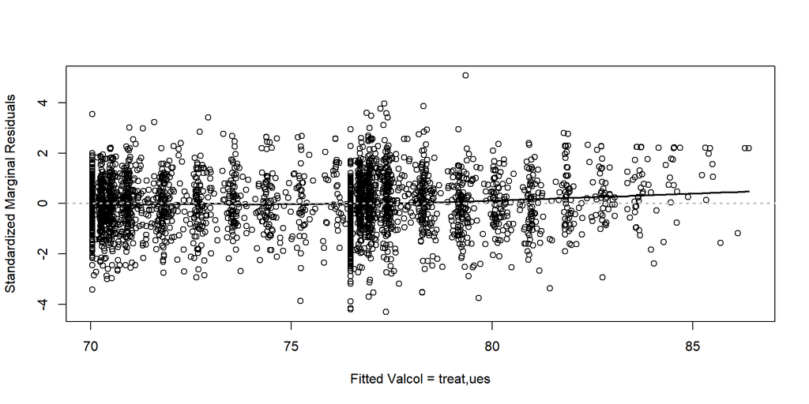

```r
######### Análise de resíduos
plotResid <- function(x, y, col.loess ="black",...){
  plot(x, y, ...)
  lines(lowess(x, y), col = col.loess, lwd = 2)
  abline(h=0, lty=3, col = "grey", lwd=2)
}


#residuos do processo longitudinal

msres1 <- residuals(jmfit_lag, process = "Longitudinal", type = "stand-Marginal")
ssres1 <-  residuals(jmfit_lag, process = "Longitudinal", type = "stand-Subject")
#preditos

msfit1 <- fitted(jmfit_lag, process = "Longitudinal", type = "Marginal")

plotResid(msfit1, msres1,
           xlab ="Fitted Valcol = treat,ues", ylab = "Standardized Marginal Residuals")
```

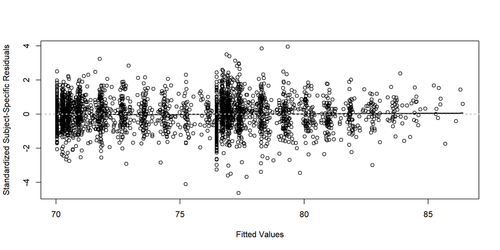

```r
plotResid(msfit1, ssres1,
          xlab ="Fitted Values", ylab = "Standardized Subject-Specific Residuals")
```

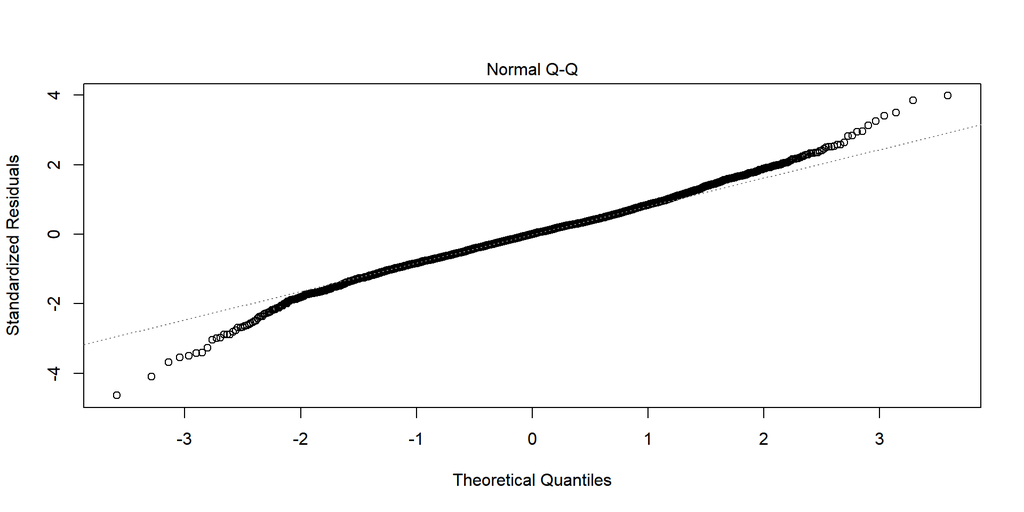

```r
plot(jmfit, which = 2)
```

### Resíduos da parte de sobrevivência

Para avaliar o ajuste do modelo para o processo de sobrevivência, podemos usar os resíduos Martingale, e os resíduos de Cox-Snell.

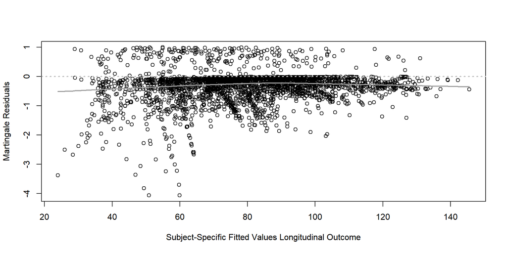

```r
#Resíduos do processo de sobrevivência
martres1 <- residuals(jmfit_lag, process = "Event")
csres1 <- residuals(jmfit_lag, process = "Event", type = "CoxSnell")
mi.t1 <- fitted(jmfit_lag, process = "Longitudinal", type ="EventTime")

sfit1 <- survfit(Surv(csres1, death) ~ 1, prothros )

plotResid(mi.t1, martres1, col.loess ="grey62",
          ylab = "Martingale Residuals",
          xlab = "Subject-Specific Fitted Values Longitudinal Outcome")
```

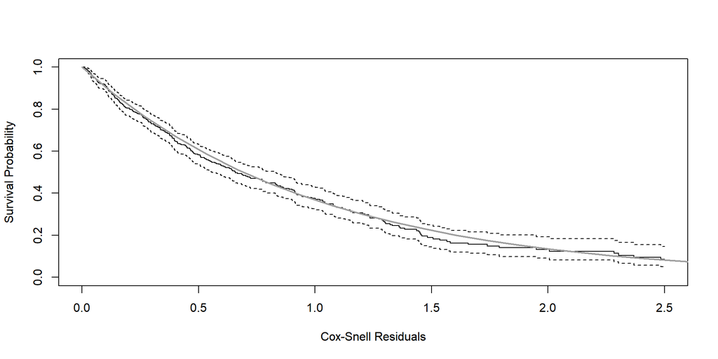

```r
plot(sfit1, mark.time = FALSE, conf.int = TRUE, xlim = c(0,2.5),
     xlab = "Cox-Snell Residuals", ylab = "Survival Probability")
curve(exp(-x), from = 0, to = max(prothros$Time), add = TRUE,
      col = "grey62", lwd = 2)
```

# Bônus: Inclinação tempo-dependente

É possível analizar outros aspectos da trajetória longitudinal estimada, além dos valores assumidos em determinado tempo $t$.

Na parametrização de inclinação tempo-dependente, introduzimos outro termo $m'_i(t)$ que representa a derivada de $m_i(t)$ com respeito ao tempo. Assim, é possível quantificar a relação entre a inclinação da trajetória longitudinal e o risco de evento no tempo $t$.

$$\begin{equation}
h_i(t) = h_0(t) \exp \{\pmb\gamma' \pmb w_i + \alpha_1 m_i (t)
+\alpha_2 m_i'(t) \}.
\end{equation}$$

Para ajustar esse modelo usando o pacote `JM`, é necessário especificar os termos do modelo longitudinal que restam na derivada:

```r
summary(Lmefit)
```

```
## Linear mixed-effects model fit by REML
##   Data: prothro
##        AIC      BIC    logLik
##   26557.59 26605.54 -13270.79
##
## Random effects:
##  Formula: ~time | id
##  Structure: General positive-definite, Log-Cholesky parametrization
##             StdDev   Corr
## (Intercept) 18.41625 (Intr)
## time         3.62703 -0.001
## Residual    17.34742
##
## Fixed effects:  pro ~ time * treat
##                         Value Std.Error   DF  t-value p-value
## (Intercept)          76.87210 1.3360422 2478 57.53718  0.0000
## time                  1.00848 0.4218889 2478  2.39038  0.0169
## treatprednisone      -7.32381 1.9123739  486 -3.82970  0.0001
## time:treatprednisone  0.51347 0.6047411 2478  0.84908  0.3959
##  Correlation:
##                      (Intr) time   trtprd
## time                 -0.191
## treatprednisone      -0.699  0.133
## time:treatprednisone  0.133 -0.698 -0.201
##
## Standardized Within-Group Residuals:
##          Min           Q1          Med           Q3          Max
## -4.583339529 -0.566837093  0.002032327  0.544491368  3.886901146
##
## Number of Observations: 2968
## Number of Groups: 488
```

No modelo original, temos $\beta_0$, $\beta_1$ que multiplica o tempo, $\beta_2$ que multiplica a indicadora de tratamento com prednisona, $\beta_3$ que multiplica tanto o tempo como a indicadora de tratamento, $b_{i0}$ e $b_{i1}$ que multiplica o tempo.

Ao derivar esta equação em relação ao tempo, resta $\beta_1$, $\beta_3*treat$, o segundo e o quarto efeito fixo do modelo, e $b_{i1}$, o segundo efeito aleatório.

```r
dform <- list(fixed = ~ 1 + treat, indFixed = c(2, 4),
              random = ~ 1, indRandom = 2)

jmfit_2 <- update(jmfit, parameterization = "slope", derivForm = dform)

summary(jmfit_2)
```

```
##
## Call:
## jointModel(lmeObject = Lmefit, survObject = Coxfit, timeVar = "time",
##     parameterization = "slope", method = "weibull-PH-GH", derivForm = dform)
##
## Data Descriptives:
## Longitudinal Process     Event Process
## Number of Observations: 2968 Number of Events: 292 (59.8%)
## Number of Groups: 488
##
## Joint Model Summary:
## Longitudinal Process: Linear mixed-effects model
## Event Process: Weibull relative risk model
## Parameterization: Time-dependent slope
##
##    log.Lik      AIC      BIC
##  -14031.93 28087.86 28138.15
##
## Variance Components:
##               StdDev    Corr
## (Intercept)  17.6605  (Intr)
## time          3.9486  0.5492
## Residual     17.7211
##
## Coefficients:
## Longitudinal Process
##                        Value Std.Err z-value p-value
## (Intercept)          78.1826  1.1994 65.1839 <0.0001
## time                 -0.3896  0.3571 -1.0910  0.2753
## treatprednisone      -7.7089  1.9540 -3.9451  0.0001
## time:treatprednisone  0.0555  0.5306  0.1047  0.9166
##
## Event Process
##                   Value Std.Err z-value p-value
## (Intercept)     -2.3936  0.2846 -8.4099 <0.0001
## treatprednisone  0.1966  0.1950  1.0081  0.3134
## Assoct.s        -0.3807  0.0468 -8.1352 <0.0001
## log(shape)       0.1671  0.0852  1.9607  0.0499
##
## Scale: 1.1818
##
## Integration:
## method: Gauss-Hermite
## quadrature points: 9
##
## Optimization:
## Convergence: 0
```

```r
exp(-0.3807)
```

```
## [1] 0.6833829
```

```r
exp(0.3807)
```

```
## [1] 1.463309
```

# Referências

RIZOPOULOS, D. Joint Models for Longitudinal and Time-to-Event Data: With Applications in R. [S.l.]: CRC Press, 2012. Google-Books-ID: xotIpb2duaMC. ISBN 978-1-4398-7286-4.

WU, L.; LIU, W.; YI, G. Y.; HUANG, Y. Analysis of Longitudinal and Survival Data: Joint Modeling, Inference Methods, and Issues. Journal of Probability and Statistics, v. 2012, p. e640153, dez. 2011. ISSN 1687-952X. Publisher: Hindawi. Disponível em: https://www.hindawi.com/journals/jps/2012/640153/.

WULFSOHN, M. S.; TSIATIS, A. A. A Joint Model for Survival and Longitudinal Data Measured with Error. Biometrics, v. 53, n. 1, p. 330–339, 1997. ISSN 0006-341X. Publisher: [Wiley, International Biometric Society]. Disponível em: https://www.jstor.org/stable/2533118